Happy New Year everyone! For the last post of the year, I thought I’d have a little fun with the new animation package in R. It’s actually really easy to use. I recently had some fun with it when I presented my research at an electronic poster session, and had an animated movie embedded into the powerpoint.

#### 1. Tracing a regression line

Let’s start with first plot that traces a regression line over the scatterplot of the points. We’ll make up some data and fit a loess of two degrees (default). You could easily do this with any kind of regression.

```r
#make up some data
tracedat<-data.frame(x=rnorm(1000,0,1))
tracedat$y<-abs(tracedat$x)*2+rnorm(1000,0,3)

#predict a spline fit and add predicted values to the dataframe
loess_fit <- loess(y ~ x, tracedat)
tracedat$predict_y<-predict(loess_fit)
```

Now let’s make the completed scatterplot and loess line using **ggplot**. If you need help on how to plot a scatterplot in ggplot, see my post here: [ggplot2: Cheatsheet for Scatterplots](http://rforpublichealth.blogspot.com/2013/11/ggplot2-cheatsheet-for-scatterplots.html).

It is possible to use **stat_smooth()** within **ggplot** to get the loess fit without predicting the values and using **geom_line()**, but the predicted values are going to make it easier to make the animation.

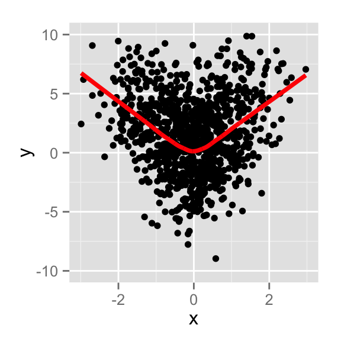

```r
#plot finished scatterplot with loess fit
ggplot(tracedat, aes(x,y)) +
    geom_point() +
    geom_line(data=tracedat, aes(x,predict_y), color="red", size=1.3) +
    scale_x_continuous(limits=c(-3, 3)) +
    scale_y_continuous(limits=c(-10, 10))
```

Now what we need is for the loess fit to appear bit by bit, so to do this we’ll cut off the dataframe for **geom_line** for only those x-values up to a certain cutoff x-value (by subsetting the dataframe called tracedat in the **geom_line** statement). Then we’ll just keep moving that cutoff forward as we iterate over the range of all x-values.

First, we will build a function that takes the cutoff value as an argument. Then we can pass whatever value of x we want and it will only graph the line up to that cutoff. Notice how the scatterplot itself, however, is for the full data.

For more on how to write functions, see my post about them, [here](http://rforpublichealth.blogspot.com/2014/06/how-to-write-and-debug-r-function.html).

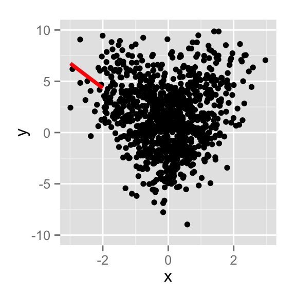

```r
#function to draw the scatterplot, but the curve fit only up to whatever index we set it at
draw.curve<-function(cutoff){
  a<-ggplot(tracedat, aes(x,y)) +
    geom_point() +
    geom_line(data=tracedat[tracedat$x<cutoff,], aes(x,predict_y), color="red", size=1.3) +
    scale_x_continuous(limits=c(-3, 3)) +
    scale_y_continuous(limits=c(-10, 10))

  print(a)
}

#try it out: draw curve up to cutoff x-value of -2
draw.curve(cutoff=-2)
```

Almost done! Now we just need to iterate the **draw.curve()** function we just created for the full range of the values of x. So we’ll use **lapply()** to iterate the **draw.curve()** function over the sequence of i=-3 to 3 (incrementing by .2) and we call the **draw.curve()** function for each value of i. Finally, we’ll use the **saveGIF()** function from the animation package to stick all the images together successively into one GIF.

The interval argument tells you how fast the GIF will move from one image to the next, and you can give it a name. If you don’t want the GIF to loop back to the start again, you would add an argument “loop=FALSE” into the function call.

```r
#function to iterate over the full span of x-values
trace.animate <- function() {
  lapply(seq(-3,3,.2), function(i) {
    draw.curve(i)
  })
}

#save all iterations into one GIF
saveGIF(trace.animate(), interval = .2, movie.name="trace.gif")
```

#### 2. Diverging density plots

We’ll make up some data and plot the “before” plot to start. Notice that we’ll use **aes_string** rather than simply **aes** in the ggplot statement in order to be able to pass the data in as an argument when we turn this into a function. More on how to plot distributions using **ggplot** in my post [ggplot2: Cheatsheet for Visualizing Distributions](http://rforpublichealth.blogspot.ie/2014/02/ggplot2-cheatsheet-for-visualizing.html).

It’s important to set the scale for x and y axes so that when we iterate over the two plots, we have the same dimensions each time. The alpha argument in **geom_density** makes the colors more transparent.

```r
dist.data<-data.frame(base=rnorm(5000, 0, 3),
                      follow=rnorm(5000, 0, 3),
                      type=c(rep("Type 1",2500),rep("Type 2",2500)))
dist.data$follow<-ifelse(dist.data$type=="Type 2", dist.data$follow+12, dist.data$follow)

#plot one to make sure it's working. Use aes_string rather than aes
p<-ggplot(dist.data, aes_string("base", fill="type")) +
  geom_density(alpha=0.5) +
  theme(legend.position="bottom") +
  scale_x_continuous(limits=c(-10, 20)) +
  scale_y_continuous(limits=c(0, 0.20)) +
  scale_fill_manual("", labels=c("Type 1", "Type 2"), values = c("orange","purple")) +
  labs(x="Score",y="Density", title="title")
```

Again, we write two functions: one that draws a density plot based on the arguments passed to it (**plot.dens()**), and one that iterates over the two different plots (called **distdiverge.animate()**). In the **dist.diverge.animate()** function, we pass the plot.item (which is a character class that aes_string will understand as the name of the column in dist.data to plot), and the title, which is also a character class.

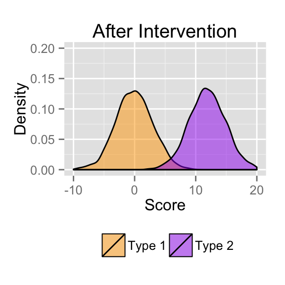

```r
#function that plots a density plot with arguments for the variable to plot and the title
plot.dens<-function(plot.item, title.item){
  p<-ggplot(dist.data, aes_string(plot.item, fill="type"))+
    geom_density(alpha=0.5) +
    theme(legend.position="bottom") +
    scale_x_continuous(limits=c(-10, 20)) +
    scale_y_continuous(limits=c(0, 0.20)) +
    scale_fill_manual("", labels=c("Type 1", "Type 2"), values = c("orange","purple"))+
    labs(x="Score",y="Density", title=title.item)

  print(p)
}

#try it out - plot it for the follow data with the title "After Intervention"
plot.dens(plot.item="follow", title.item="After Intervention")
```

```r
#function that iterates over the two different plots
distdiverge.animate <- function() {
  items<-c("base", "follow")
  titles<-c("Before Intervention","After Intervention")
  lapply(seq(1:2), function(i) {
    plot.dens(items[i], titles[i])
  })
}
```

We’ll make the interval slower so there’s more time to view each plot before the GIF moves to the next one.

```r
#save in a GIF
saveGIF(distdiverge.animate(), interval = .65, ,movie.name="dist.gif")
```

#### 3. Happy New Year plot

Finally, to make the fun “Happy 2015” plot, we just make a black background plot, create new random data at every iteration for the snow, and then iterate over the letters of the sign.

Let’s start with the first plot for the letter “H”. We create some data and the objects that will hold the letters of the sign that scrolls through, the colors (I use the colorspace package to pull some colors for me for this), and the x- and y-coordinates for where we want the letters to go. You can think about randomizing the coordinates too. Then we just plot a scatterplot and use annotate to add the letter to it.

```r
#create dataset
happy2015<-data.frame(x=rnorm(500, 0, 1.5), y=rnorm(500, 0, 1.5), z=rnorm(500,0,1.5))

#create objects to hold the letters, colors, and x and y coordinates that we will scroll through
sign<-c("H","A","P","P","Y","2","0","1","5","!!")
colors <- rainbow_hcl(10, c=300)
xcoord<-rep(c(-2, -1, 0, 1, 2),2)
ycoord<-c(2, 1.7, 2.1, 1.5, 2, -.5, 0, -1, -.8, -.7)
```

We set up the ggplot theme and test the first plot.

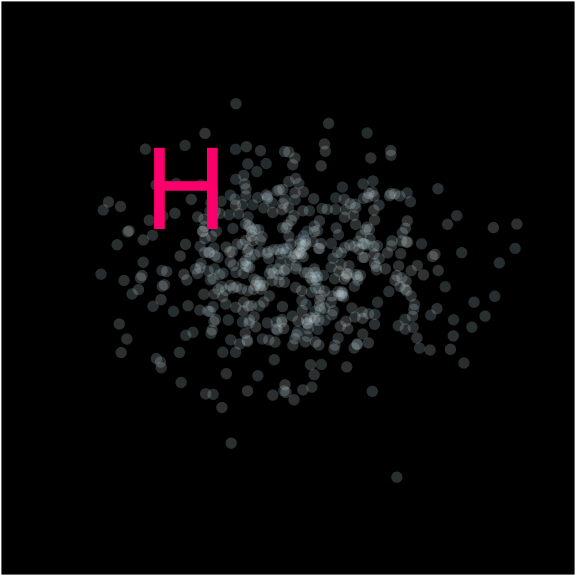

```r
#set up the theme in an object (get rid of axes, grids, and legend)
theme.both<- theme(legend.position="none",
                   panel.background = element_blank(),
                   axis.ticks = element_blank(),
                   axis.line = element_blank(),
                   axis.text.x = element_blank(),
                   axis.text.y = element_blank(),
                   plot.background = element_rect(fill = "black"),
                   panel.grid.major = element_blank(),
                   panel.grid.minor = element_blank())

#plot the first letter (set index=1 to get the first element of color, letter, and coordinates)
index<-1
ggplot(happy2015, aes(x, y, alpha = z, color=z)) +
    geom_point(alpha=0.2) + labs(title="", x="", y="") +
    theme.both +
    scale_colour_gradient(low = "white", high="lightblue")+
    annotate("text", x=xcoord[index], y=ycoord[index], size=15, label=sign[index], color=colors[index])
```

Finally, we again go through the structure of two functions - one to draw a plot based on the “index” we give it as an argument, and one to iterate through all the letters using lapply(). Notice we put the dataframe statement in the first function - this will make the scatterplot different every time, rather than stay static, which is more festive (more or less like falling snow). Again, we save it in a GIF, with a slow interval in order to give time to read it.

```r
#set up function to create a new dataset, plot it, and annotate it by an index argument
draw.a.plot<-  function(index){

  #make up a new dataframe
  happy2015<-data.frame(x=rnorm(500, 0, 1.5), y=rnorm(500, 0, 1.5), z=rnorm(500,0,1.5))

  #plot according to the index passed
  g<-ggplot(happy2015, aes(x, y, alpha = z, color=z)) +
      geom_point(alpha=0.2) + labs(title="", x="", y="") +
      theme.both +
      scale_colour_gradient(low = "white", high="lightblue")+
      annotate("text", x=xcoord[index], y=ycoord[index], size=15, label=sign[index], color=colors[index])

  #print out the plot
  print(g)
}

#set up function to loop through the draw.a.plot() function
loop.animate <- function() {
  lapply(1:length(sign), function(i) {
    draw.a.plot(i)
  })
}

#save the images into a GIF
saveGIF(loop.animate(), interval = .5, movie.name="happy2015.gif")
```

Other great sources for learning animations:

- [Analysis with Programming](http://alstatr.blogspot.com/2014/02/r-animating-2d-and-3d-plots.html)
- [TRinker’s R Blog](http://trinkerrstuff.wordpress.com/2013/05/11/animations-understood-5/)